# Practical Machine Learning

Yuani

19 November 2015

## 1. Download Data

The data for this project come from this source: http://groupware.les.inf.puc-rio.br/har. When importing data, all empty cells were replaced in “NA”.str

```r
setwd("C:\\Users\\ychen06\\Documents\\IDA MOOC\\Git\\PracticalMachineLearning")
data_training<-read.csv("pml-training.csv",na.strings=c(""," ","NA"))
data_testing<-read.csv("pml-testing.csv",na.strings=c(""," ","NA"))
```

## Clean Dataset

There are 160 different variables in the datasets provided. However, not all variables can be used in developing our predictions as the entire variable consist of null values.

We first clean the data set to select only variables with values that can be used for analysis.Columns with complete “NA” or blanks are removed.

We also generated a second table consisting of all the predictor variables and the final desired predicted value “classe”. These variables were selected based on the goal of using data from accelerometers on the bell, forearm, arm and dumbbell.

```r
data_training_cleaned<-data_training[ , colSums(is.na(data_training))== 0 ]
data_predictor<- data_training_cleaned[,grepl("belt|forearm|arm|dumbbell|classe",names(data_training_cleaned))]

data_testing_cleaned<-data_testing[ , colSums(is.na(data_testing))== 0 ]
data_testing_cleaned<- data_testing_cleaned[,grepl("belt|forearm|arm|dumbbell|classe",names(data_testing_cleaned))]
```

This results in 53 variables including “classe” which is our predcted outcome.

```r
names(data_predictor)
```

```
##  [1] "roll_belt"            "pitch_belt"           "yaw_belt"
##  [4] "total_accel_belt"     "gyros_belt_x"         "gyros_belt_y"
##  [7] "gyros_belt_z"         "accel_belt_x"         "accel_belt_y"
## [10] "accel_belt_z"         "magnet_belt_x"        "magnet_belt_y"
## [13] "magnet_belt_z"        "roll_arm"             "pitch_arm"
## [16] "yaw_arm"              "total_accel_arm"      "gyros_arm_x"
## [19] "gyros_arm_y"          "gyros_arm_z"          "accel_arm_x"
## [22] "accel_arm_y"          "accel_arm_z"          "magnet_arm_x"
## [25] "magnet_arm_y"         "magnet_arm_z"         "roll_dumbbell"
## [28] "pitch_dumbbell"       "yaw_dumbbell"         "total_accel_dumbbell"
## [31] "gyros_dumbbell_x"     "gyros_dumbbell_y"     "gyros_dumbbell_z"
## [34] "accel_dumbbell_x"     "accel_dumbbell_y"     "accel_dumbbell_z"
## [37] "magnet_dumbbell_x"    "magnet_dumbbell_y"    "magnet_dumbbell_z"
## [40] "roll_forearm"         "pitch_forearm"        "yaw_forearm"
## [43] "total_accel_forearm"  "gyros_forearm_x"      "gyros_forearm_y"
## [46] "gyros_forearm_z"      "accel_forearm_x"      "accel_forearm_y"
## [49] "accel_forearm_z"      "magnet_forearm_x"     "magnet_forearm_y"
## [52] "magnet_forearm_z"     "classe"
```

The predicted outcomes in our training set is distributed as follow:

```r
summary(data_predictor$classe)
```

```
##    A    B    C    D    E
## 5580 3797 3422 3216 3607
```

## Prediction Modeling

```r
library(caret)
library(rpart)
inTrain <- createDataPartition(y=data_predictor$classe, p=0.7, list=FALSE)
train_trainingset <- data_predictor[inTrain,]
train_testingset<- data_predictor[-inTrain,]
```

```r
set.seed(1212)
```

```r
#Decision Tree Method
modFit<-train(classe ~ . ,method="rpart",data=train_trainingset)
print(modFit$finalModel)
```

```
## n= 13737
##
## node), split, n, loss, yval, (yprob)
##       * denotes terminal node
##
##  1) root 13737 9831 A (0.28 0.19 0.17 0.16 0.18)
##    2) roll_belt< 129.5 12505 8647 A (0.31 0.21 0.19 0.18 0.11)
##      4) pitch_forearm< -33.95 1103    8 A (0.99 0.0073 0 0 0) *
##      5) pitch_forearm>=-33.95 11402 8639 A (0.24 0.23 0.21 0.2 0.12)
##       10) magnet_dumbbell_y< 439.5 9614 6908 A (0.28 0.18 0.24 0.19 0.1)
##         20) roll_forearm< 123.5 5978 3544 A (0.41 0.18 0.18 0.17 0.057) *
##         21) roll_forearm>=123.5 3636 2419 C (0.075 0.18 0.33 0.23 0.18) *
##       11) magnet_dumbbell_y>=439.5 1788  883 B (0.032 0.51 0.043 0.23 0.19) *
##    3) roll_belt>=129.5 1232   48 E (0.039 0 0 0 0.96) *
```

```r
library(rattle)
```

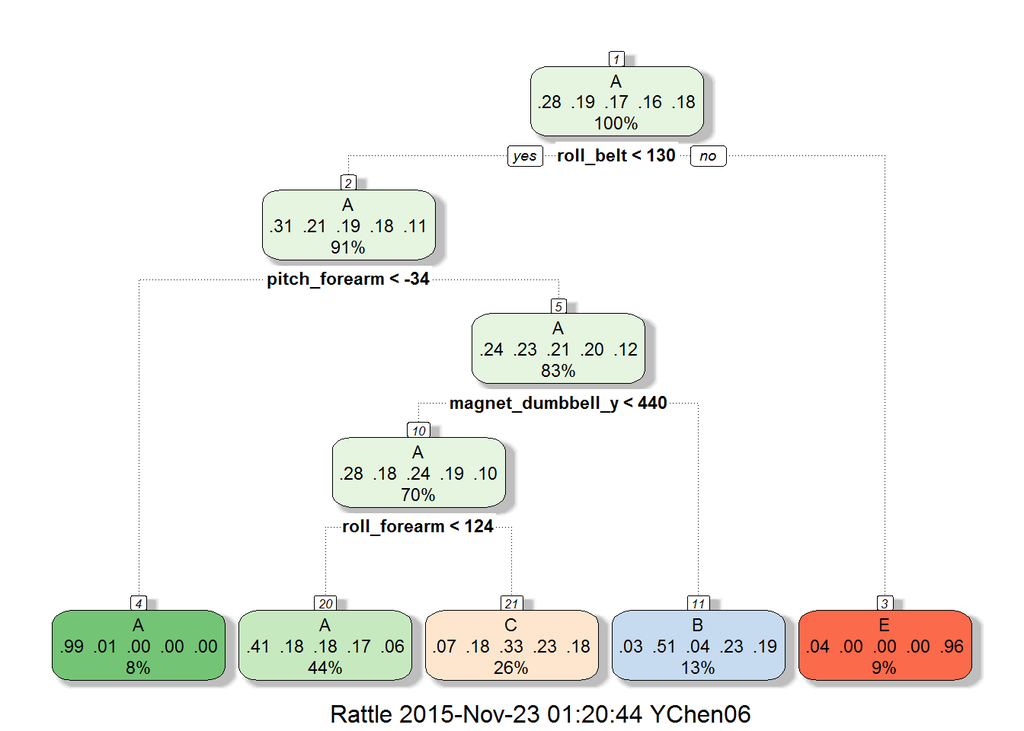

```r
rattle()
fancyRpartPlot(modFit$finalModel)
```

```r
prediction_results_tree<-predict(modFit,newdata=train_testingset)
cm1<-confusionMatrix(prediction_results_tree, train_testingset$classe)
```

```r
#Random Forest Method
library(randomForest)
modFit2<-randomForest(classe~., data=train_trainingset, ntree = 500)
print(modFit2$finalModel)
```

```r
prediction_results_rf<-predict(modFit2,newdata=train_testingset)
cm2<-confusionMatrix(prediction_results_rf, train_testingset$classe)
```

## Selection Prediction Model

Comparing the level of specificity and sensitivty bewteen the 2 models, the random forest shows better results, with an accuracy of 99%. We will therefore select the random forest model on the testing data set to predict the ‘classe’.

```r
print(cm1)
```

```
## Confusion Matrix and Statistics
##
##           Reference
## Prediction    A    B    C    D    E
##          A 1491  482  484  440  150
##          B   24  381   32  157  127
##          C  133  276  510  367  290
##          D    0    0    0    0    0
##          E   26    0    0    0  515
##
## Overall Statistics
##
##                Accuracy : 0.4923
##                  95% CI : (0.4794, 0.5051)
##     No Information Rate : 0.2845
##     P-Value [Acc > NIR] : < 2.2e-16
##
##                   Kappa : 0.3367
##  Mcnemar's Test P-Value : NA
##
## Statistics by Class:
##
##                      Class: A Class: B Class: C Class: D Class: E
## Sensitivity            0.8907  0.33450  0.49708   0.0000  0.47597
## Specificity            0.6305  0.92836  0.78061   1.0000  0.99459
## Pos Pred Value         0.4893  0.52843  0.32360      NaN  0.95194
## Neg Pred Value         0.9355  0.85321  0.88025   0.8362  0.89390
## Prevalence             0.2845  0.19354  0.17434   0.1638  0.18386
## Detection Rate         0.2534  0.06474  0.08666   0.0000  0.08751
## Detection Prevalence   0.5178  0.12251  0.26780   0.0000  0.09193
## Balanced Accuracy      0.7606  0.63143  0.63884   0.5000  0.73528
```

```r
print(cm2)
```

```
## Confusion Matrix and Statistics
##
##           Reference
## Prediction    A    B    C    D    E
##          A 1673    1    0    0    0
##          B    1 1137    4    0    0
##          C    0    1 1020    6    0
##          D    0    0    2  958    2
##          E    0    0    0    0 1080
##
## Overall Statistics
##
##                Accuracy : 0.9971
##                  95% CI : (0.9954, 0.9983)
##     No Information Rate : 0.2845
##     P-Value [Acc > NIR] : < 2.2e-16
##
##                   Kappa : 0.9963
##  Mcnemar's Test P-Value : NA
##
## Statistics by Class:
##
##                      Class: A Class: B Class: C Class: D Class: E
## Sensitivity            0.9994   0.9982   0.9942   0.9938   0.9982
## Specificity            0.9998   0.9989   0.9986   0.9992   1.0000
## Pos Pred Value         0.9994   0.9956   0.9932   0.9958   1.0000
## Neg Pred Value         0.9998   0.9996   0.9988   0.9988   0.9996
## Prevalence             0.2845   0.1935   0.1743   0.1638   0.1839
## Detection Rate         0.2843   0.1932   0.1733   0.1628   0.1835
## Detection Prevalence   0.2845   0.1941   0.1745   0.1635   0.1835
## Balanced Accuracy      0.9996   0.9986   0.9964   0.9965   0.9991
```

## Prediction Results

```r
#model used
print(modFit2$finalModel)
```

```r
prediction_results_final<-predict(modFit2,newdata=data_testing_cleaned)
final_table<-data_testing_cleaned
final_table$Prediction<-prediction_results_final
final_table
```

[output not shown]

[output cut: 237 more lines]